# Resting state functional magnetic resonance imaging and neural network classified autism and control - ScienceDirect

## Outline

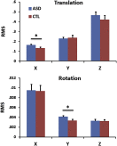

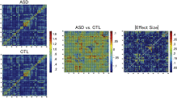

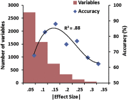

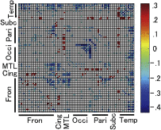

[figure not shown]

## [Cortex](https://www.sciencedirect.com/science/journal/00109452)

[Volume 63](https://www.sciencedirect.com/science/journal/00109452/63/supp/C), February 2015, Pages 55-67

# Research report Resting state functional magnetic resonance imaging and neural network classified autism and control

[TetsuyaIidaka](https://www.sciencedirect.com/science/article/abs/pii/S0010945214002640#!)

## Abstract

Although the neurodevelopmental and genetic underpinnings of [autism spectrum disorder](https://www.sciencedirect.com/topics/neuroscience/pervasive-developmental-disorders) (ASD) have been investigated, the etiology of the disorder has remained elusive, and clinical diagnosis continues to rely on symptom-based criteria. In this study, to classify both control subjects and a large sample of patients with ASD, we used [resting state functional magnetic resonance imaging](https://www.sciencedirect.com/topics/psychology/resting-state-functional-magnetic-resonance-imaging) (rs-fMRI) and a [neural network](https://www.sciencedirect.com/topics/psychology/neural-network). Imaging data from 312 subjects with ASD and 328 subjects with typical development was downloaded from the multi-center research project. Only subjects under 20 years of age were included in this analysis. Correlation matrices computed from rs-fMRI time-series data were entered into a probabilistic neural network (PNN) for classification. The PNN classified the two groups with approximately 90% accuracy (sensitivity = 92%, specificity = 87%). The accuracy of classification did not differ among the institutes, or with respect to experimental and imaging conditions, sex, handedness, or intellectual level. Medication status and degree of head movement did not affect accuracy values. The present study indicates that an intrinsic connectivity matrix produced from rs-fMRI data could yield a possible biomarker of ASD. These results support the view that altered network connectivity within the brain contributes to the neurobiology of ASD.

## Keywords

Developmental disorder

Brain imaging

Diagnosis

Machine learning

Classifier

Copyright © 2014 Elsevier Ltd. All rights reserved.